[figure not shown]

# Septiembre 29 a Noviembre 3 Martes 6-8 p.m. Tutorias: Sábados por la mañana

## Información General

[figure not shown]

Las redes aparecen en prácticamente todos los entornos de la vida humana. Los seres humanos se organizan de manera natural construyendo redes (sociales, económicas, biológicas), nuestras familias y vecindarios son redes importantes para nosotros. Las organizaciones funcionan construyendo redes complejas e interconectadas de asociaciones comerciales y financieras. La salud pública se promueve a través de asociaciones y coaliciones de gobiernos. Las naciones están conectadas entre sí a través de sistemas de migración, comercio, etc. Por otro lado, las redes no humanas existen casi en cualquier lugar que mires, los genes y las proteínas interactúan entre sí a través de redes biológicas complejas, de la misma manera, el cerebro humano es una red compleja. El progreso social y científico es impulsado por un proceso de difusión de la innovación, mediante el cual la información se propaga a través de sistemas sociales conectados. La Ciencia de Redes ofrece un lenguaje común y varios métodos a través de los cuales diferentes disciplinas interactúan y tratan de resolver problemas comunes. Ofrece una metodología general y poderosa para modelar y representar interacciones simples y complejas. Este curso se enfoca en estudiar el marco conceptual y aplicado general de la ciencia de redes. Se estudiarán conceptos fundamentales, métodos comúnmente utilizados y de vanguardia. Los temas principales incluyen, medidas de centralidad de redes, modelos, algunos conceptos básicos de métodos estadísticos y de aprendizaje automático, y sus aplicaciones en contexto; asimismo, la resolución de problemas del mundo real se ilustrará mostrando varios ejemplos de manera práctica.

## Profesores

[figure not shown]

#### [Ph. D., Luis Fernado Niño Full Professor,UNAL](https://scholar.google.com.co/citations?user=q__sQE8AAAAJ&hl=en)

#### [M.Sc., Alfonso Meléndez Full Professor,UECI](http://profesores.is.escuelaing.edu.co/~amelendez/HojaDeVida/HojaDeVida.html)

## Cronograma Semanal

[output not shown]

## Libros

### Libros de Referencia

1. Filippo Menczer, A first course in Network Science
2. [Michelle Coscia, Atlas for the network Scientist](https://www.dropbox.com/s/drnlweij592bqgz/sna_book.pdf?dl=1)
3. [Albert Lazslo Barabasi, Network Science](http://networksciencebook.com/)

### Libros Adicionales

1. [Mark Newman: Networks an Introduction](https://www.dropbox.com/s/s5od0hm02pw6yw8/Mark%20Newman%20-%20Networks-Oxford%20University%20Press%20%282018%29.pdf?dl=1)
2. [Klienberg, Easley Networks Crowds and Markets](https://www.dropbox.com/s/wfjpbubt6cuae3l/KleinbergNetworks%2C%20Crowds%2C%20and%20Markets.pdf?dl=1)
3. [Van Steen,Graph Theory and Complex Networks](https://www.dropbox.com/s/ur6685tqwwq2jt7/van%20Steen%20-%20Graph%20Theory%20and%20Complex%20Networks_%20An%20Introduction.pdf?dl=1)
4. [Dan Centola , How Behaviour Spreads](https://www.dropbox.com/s/wq8as0z60m0azua/Centola%20Behaviour.pdf?dl=1)
5. [Duncan Watts, Six Degrees of Separation](https://www.dropbox.com/s/pnnndn27i6x5v7m/Duncan%20J.%20Watts%20-%20Six%20Degrees_.pdf?dl=1)
6. [John Scott, Social Network Analysis](https://www.dropbox.com/s/wazbwtf7lwzmfqs/John%20Scott%20-%20Social%20Network%20Analysis-Sage%20Pubns%20Ltd%20%282017%29.pdf?dl=1)
7. [Barabasi,Watts,Newman The Structure and Dynamics of Networks](https://www.dropbox.com/s/c1rnugm5m1kapud/BarabasiWattsNewmanNetworks.pdf?dl=1)
8. [Goodfellow Ian, Bengio Yosfua, Deep Learning](https://www.deeplearningbook.org/)

### Disclosure Books(Libros de Divulgación)

1. [Christakis,Fowler Conectados](https://www.dropbox.com/s/2y4d72jo4nqr8hp/%28Pensamiento%29%20Nicholas%20A.%20Christakis%20%26%20James%20H.%20Fowler%20-%20Conectados-Taurus%20%282010%29.pdf?dl=1)
2. Matthew Jackson, the human network
3. [James Surowiecki, The Wisdom of Crowds](https://www.dropbox.com/s/gm794cf884dy8rd/James%20Surowiecki%20-%20The%20Wisdom%20of%20Crowds-Anchor%20%282005%29.pdf?dl=1)
4. [Mark Buchanan, Nexus](https://www.dropbox.com/s/zlzqzepoo7y5jmb/Mark%20Buchanan%20-%20Nexu.pdf?dl=1)
5. [Barabasi, Linked](https://www.dropbox.com/s/mre7h7nurlbnq6s/Barabasi%20Linked_%20The%20New%20Science%20of%20Networks.pdf?dl=1)

### Tesis de Maestría

[Knetch, Friendship selection and Friendship Influence](https://www.dropbox.com/s/7sebmzk0a5ya887/TesisKnecht.pdf?dl=1)

[Zhuo Chen, Agent Based model For Diffusion in Networks](https://www.dropbox.com/s/cu8ys0pt797xaf8/ZhuoChen_Thesis.pdf?dl=1)

[Contreras, Detección de Comunidades en Redes](https://www.dropbox.com/s/3um36k5cl5jcfmr/Valparaiso2015.pdf?dl=1)

### Redes en Pocas Palabras

[Borgatti, Network Analysis in the Social Sciences](https://www.dropbox.com/s/3euf3kag12pufjc/Borgatti%20S.%20et%20al.%20%282009%29%20Network%20Analysis%20in%20the%20Social%20Sciences.pdf?dl=1)

[NetSciEd, Network Literacy](https://www.dropbox.com/s/6h4n4hb0whh7cpe/Network-Literacy-high-res.pdf?dl=1)

[Newman, Structure of Complex Networks](https://www.dropbox.com/s/qfzvnyy7be0de1z/Newman%20Strucuture%20Complex%20networks.pdf?dl=1)

### Libros que usan Networkx

Edward Platt, Network Science with Python

[Dmitry Zynoviev, Complex Network Analysis](https://www.dropbox.com/s/84hpigjk4evf3r1/Dmitry%20Zinoviev%20-%20Complex%20Network%20Analysis%20in%20Python.pdf?dl=1)

[Hiroki Sayama,Modeling and Analysis of Complex Systems](https://www.dropbox.com/s/iylpt8mornj3k82/Hiroki%20Sayama%20-%20Introduction%20to%20the%20Modeling%20and%20Analysis%20of%20Complex%20Systems-Open%20SUNY%20Textbooks%20%282015%29.pdf?dl=1)

Maxsin Tsvetovat, Social Network Analysis for Startups

### Libros que usan Igraph

[Douglas Luke, A user Guide to network Analysis in R](https://www.dropbox.com/s/8e06fvkh1ujq9kg/Douglas%20A.%20Luke%20-%20A%20User%27s%20Guide%20to%20Network%20Analysis%20in%20R-Springer%20%282015%29.pdf?dl=1)

[Katherine Ognyanova, Network Analysis and Visualization with R](https://www.dropbox.com/s/i5mnoifliihpuj6/Katherine%20Ognyanova.%20-%20Network%20Analysis%20and%20Visualization%20with%20R%20and%20igraph.pdf?dl=1)

[Kolaczyk, Statistical Analysis of network Data](https://www.dropbox.com/s/856ka41kt716utz/KolaczykStatistical%20Analysis%20Of%20Network%20Data%20With%20R.pdf?dl=1)

## Artículos

### 1. Clasicos

1. [Watts, Strogatz : Collective Dynamics of small world Networks,1998](https://www.dropbox.com/s/kbklhcxixkgnaut/NAture_Watts_Strogatz.pdf?dl=1)
2. [Albert Barabasi, Error and Attack Tolerance of Complex Networks,1999](https://www.dropbox.com/s/icfcs0ofw0eazik/BarabasiErrorAndAttack.pdf?dl=1)
3. [Bocatelli,: Complex Networks, Structure and Dynamics](https://www.dropbox.com/s/9o2u09crc39wxy6/BocatelliNetworksStructureDynamics.pdf?dl=1)
4. [Moreno, Sociometry in the Classrooom, 1943](https://www.dropbox.com/s/2vsw3fgj3jye2qa/1943-SociometryClasroomJakobMoreno.pdf?dl=1)
5. [Mark Granovetter, The Strength of Weak Ties, 1973](https://www.dropbox.com/s/nyfv877lodd98aw/1973-GranoVetter-The%20Strength%20of%20Weak%20Ties.pdf?dl=1)
6. [Lada Adamic, The Small World Web, 1999](https://www.dropbox.com/s/sreahtgtef0llj9/1999-AdamicTheSmallWorldWeb99.pdf?dl=1)
7. [Nicholas Christakis, The Spread of Obesity, 2007](https://www.dropbox.com/s/hvlh5g9oa51sezj/2007-ChristakisSpreadOfObesity.pdf?dl=1)
8. [Alexander Vespignani Epidemic Spreading in Scale Free Networks](https://www.dropbox.com/s/b42cn7yxym1elt7/PastorVespignaniEpidemicsScaleFree.pdf?dl=1)

### 2. Redes Sociales

1. [Christakis, Sensors for Early Detection](https://www.dropbox.com/s/8v9ybdczubnb5b2/SensorsForEarlyDetection.pdf?dl=1)
2. [Jakob Moreno: Sociology in the classroom](https://www.dropbox.com/s/l6b82a7l5ty0mhh/moreno1943.pdf?dl=1)
3. [Kleinberg : The link Prediction problem for social networks](https://www.dropbox.com/s/o4fwmooetocx4sj/KleinbergLinkPrediction.pdf?dl=1)

### Artículos de Investigación

### 1. Mark Newman

1. [Mathematics of networks](https://www.dropbox.com/s/pd4igufdnujmiqe/Newman%20Mathematics%20of%20Networks.pdf?dl=1)
2. [The structure and function of networks](https://www.dropbox.com/s/v2xsjx131rfd81f/Newman%20Strucutre%20Function.pdf?dl=1)
3. [The structure and function of complex networks](https://www.dropbox.com/s/50ikivxswsarwu3/Newman%20Strucuture%20Complex%20networks.pdf?dl=1)
4. [Luseeau Newman : Identifying the role that animal plays in their social networks](https://www.dropbox.com/s/o5efdz1v8e3eu0l/DelfinesNewmanLusseau.pdf?dl=1)

### 2. Alex Bavelas (MIT)

1. [Communication patterns in Task Oriented Groups, 1950](https://www.dropbox.com/s/7frwulme6liz9f4/bavelas1950.pdf?dl=1)
2. [Experiments on the Alteration of Group Structures, 1965](https://www.dropbox.com/s/hpjgont0hp76cbj/bavelas1965.pdf?dl=1)
3. [Un ejercicio didáctico sobre transmisión de Información](https://www.dropbox.com/s/sjkfjzfp6yrxfzh/bavelas1967.pdf?dl=1)

### 3. Jennifer Neville

[Data Mining in Social Networks](https://www.dropbox.com/s/z4znrhckxzdhpxp/Data%20Mining%20in%20Social%20Networks.pdf?dl=1)

[Dependency Networks for Relational Data](https://www.dropbox.com/s/91n31wxnesvdz10/Dependency%20Networks%20for%20Relational%20Data.pdf?dl=1)

[Link Strength in Social Networks](https://www.dropbox.com/s/ltzrogq5467bpi5/LinkStrengthSocialNetworks.pdf?dl=1)

[Relational Dependency networks](https://www.dropbox.com/s/52xhcsi8j82aw16/RelationalDependencyNetworks.pdf?dl=1)

[Relational Knowledge to Discover Frauds](https://www.dropbox.com/s/zd4eiuhigy4biem/RelationalKnowledgeToDiscoverFrauds.pdf?dl=1)

## Cursos en Línea

#### ¡¡ Nuevo !! Graph Machine Learning

[Graph Neural networks, Hands on](https://www.youtube.com/playlist?list=PLB1nTQo4_y6sfLtCrGAKG_l7xOHjtYqBk)

#### Ciencia de redes

[John Mcculloch, Introduction to Social Media Analytics](https://www.youtube.com/watch?v=5Hw1OmWOLA8&list=PLnMaaCilahfY6aBe6UFJJsZ_xvYscPJiW&index=1)

[Kleingberg, Networks ,Crowds and Markets](https://learning.edx.org/course/course-v1:CornellX+INFO2040x+1T2016/home)

[Matthew Jackson, Economic Networks Coursera (Free)](https://www.coursera.org/learn/social-economic-networks)

[Aaron Clauset, Network Science](https://aaronclauset.github.io/courses/5352/)

[Andrew Beveridge, Short Course](https://www.youtube.com/watch?v=hNENd_OMlL4&list=PLlWULwPzrppXKYVyRxFt0YsgIDXiBDPNR)

[Paul Ribeiro, Network Science 2022, Porto University](https://www.dcc.fc.up.pt/~pribeiro/aulas/ns2122/index.html)

[Hiroki Sayama, Advanced Topics in Network Science 2021](https://bingweb.binghamton.edu/~sayama/SSIE641/)

[Social and Economic networks](https://www.coursera.org/learn/social-economic-networks/home/week/1)

[Curso network Science lada Adamic](https://open.umich.edu/find/open-educational-resources/information/si-508-networks-theory-application)

[Curso network science Denis Helic](https://courses.isds.tugraz.at/dhelic/netsci/index.html)

[Curso network science Leonid Zukhov](https://www.youtube.com/watch?v=1T5-BG6yngM&list=PLriUvS7IljvkGesFRuYjqRz4lKgodJgh2)

#### Redes Sociales

[Dan Centola, Network Dynamics of Social Behaviour](https://ndg.asc.upenn.edu/online-course/online-course/)

[Jennifer Golbeck, INST663 Socila Media Analysis, Maryland College park](http://www.cs.umd.edu/~golbeck/INST633o/index.shtml)

#### Machine Learning for Graphs

[Jure Luskovec, Machine learning for graphs, Stanford University 2019](http://snap.stanford.edu/class/cs224w-2020/)

#### Sistemas Complejos

[Peter Sheridan, Complex systems Vermont University](http://pdodds.w3.uvm.edu/)

[Remy Cazabet, Complex Networks-Network Science](http://cazabetremy.fr/Teaching/CN/ComplexNetworks.html)

[Mark newman, Complex Systems 2017](http://websites.umich.edu/~mejn/courses/2017/cscs535/index.html)

#### Machine learning

[Andrew Ng, Machine Learning Full Course](https://www.youtube.com/playlist?list=PLoROMvodv4rMiGQp3WXShtMGgzqpfVfbU)

## Videos

### Nuevos

[Network of the Witches](https://www.youtube.com/watch?v=fAHkJ_Dhr50&t=277s)

### Videos Informativos

1. [Flight Patterns](https://www.youtube.com/watch?v=ttH7sQ48n5k)
2. [Alan Turing Institute](https://www.youtube.com/watch?v=L6CqqlILBCI&t=4788s)
3. [Nicholas Christakis Social Networks](https://www.youtube.com/watch?v=wadBvDPeE4E)
4. [Documental the promise of network science 2017](https://www.youtube.com/watch?v=qB8YnTpCzEU)
5. [Bernie Hogan Alan Turing Inst Network Analysis](https://www.youtube.com/watch?v=i__0cG4ijrI&t=3690s)
6. [The Human Network Matthew Jackson Google Talks](https://www.youtube.com/watch?v=2C5jrYlVHJQ)
7. [Conference Raissa di Souza Santafe Institute](https://www.youtube.com/watch?v=a6U7ksiu10Y&t=2s)
8. [Dan Centola Complex Contagions Santafé Institute](https://www.youtube.com/watch?v=o0fDcUJMzkI&t=294s)
9. [Mark Newman Conference in Alan turing Institute](https://www.youtube.com/watch?v=gPSt-xs_zWQ&list=PLhUVsjVWqglS5Pnz04SbRticB4mWgu3Jk&index=8)
10. [Mark Newman Conference in Michigan about physics of complex systems](https://www.youtube.com/watch?v=2L64AhoKamE)

## Enlaces de Internet

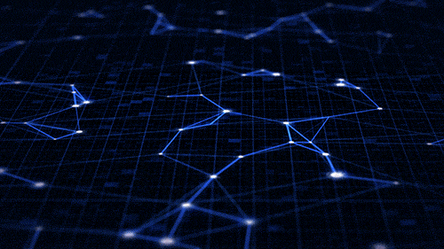

### Actividades Interactivas

¡¡¡¡ New Complexity Explorables !!!!!! (Nicky case ):

Graphs:

[Interactive Graph Theory](https://d3gt.com/)

Networks:

[The Wisdom and Madness of Crowds](https://ncase.me/crowds/)  
[Opinion Dynamics](https://www.complexity-explorables.org/explorables/echo-chambers/)

[Random Walks](https://www.complexity-explorables.org/explorables/anomalous-itinerary/)  
[Random Walks and Diffusion](https://www.complexity-explorables.org/explorables/albert-and-carl-friedrich/)

[The Giant Component](https://www.complexity-explorables.org/explorables/the-blob/)  
[!!New!!! Going Critical](https://meltingasphalt.com/interactive/going-critical/)  
[Network Growth (Clustershuck)](https://www.complexity-explorables.org/explorables/clustershuck/)  
[Communities in Weighted Networks](https://www.complexity-explorables.org/explorables/jujujajaki-networks/) [Preferential Attachment](https://www.complexity-explorables.org/explorables/knitworks/)

[The SIRS Epidemic Model](https://www.complexity-explorables.org/explorables/epidemonic/)  
[Network Vaccination](https://www.complexity-explorables.org/explorables/facebooked-flu-shots/)  
[Going Critical](https://meltingasphalt.com/interactive/going-critical/)  
[OutBreak](https://meltingasphalt.com/interactive/outbreak/)  
[Corona Simulator](https://www.washingtonpost.com/graphics/2020/world/corona-simulator/)  
[Making Sense of Covid19](http://www.r2d3.us/covid-19/)

Miscelanea:

[FireFlies](https://ncase.me/fireflies/)  
[Herd Immnuniy](https://www.complexity-explorables.org/explorables/i-herd-you/)  
[Horde of the Flies](https://www.complexity-explorables.org/explorables/horde-of-the-flies/)  
[Swarmalators](https://www.complexity-explorables.org/explorables/swarmalators/)  
[The Schelling Model](https://www.complexity-explorables.org/explorables/t-schelling-plays-go/)  
[Percolation on a Lattice](https://www.complexity-explorables.org/explorables/baristas-secret/)  
[Parable of the Polygons](https://ncase.me/polygons/)  
[Exploring Emergence](http://www.playfulinvention.com/emergence/)

### Páginas Web

[Social Networks in Movies](https://moviegalaxies.com/)

[A networked SIR Model, Animation](http://systems-sciences.uni-graz.at/etextbook/networks/sirnetwork.html)

[Small Worlds Veritasium](https://www.youtube.com/watch?v=TcxZSmzPw8k&list=PLqzLNw_z6y7S31yg_2aJj3VGCohJyPe-T&index=4)

[Organizational Networks](https://toreopsahl.com/datasets/#Cross_Parker)

[Network Animations, NetworkPages.nl](https://www.networkpages.nl/CustomMedia/)

[Networks without words Alfonso Meléndez](http://profesores.is.escuelaing.edu.co/~amelendez/RedesSinPalabras/RedesSinPalabras.html)

[Lada Adamic Web Page](http://www.ladamic.com/)

[Awesome Network Analysis Francois Briatte](https://github.com/briatte/awesome-network-analysis)

[Networks Demystified, Scott Wengart](https://scottbot.net/tag/networks-demystified/)

[Journal of Complex networks](https://academic.oup.com/comnet)

[The InterActome Atlas](http://www.interactome-atlas.org/)

[Awesome Resources of Graph Neural Networks](https://github.com/GRAND-Lab/Awesome-Graph-Neural-Networks)

[Petar Veličković, Graph Neural Netwok Resources (Twitter)](https://twitter.com/PetarV_93/status/1306689702020382720)

[Aleska Gordic, Graph Attention Networks, pyTorch](https://github.com/gordicaleksa/pytorch-GAT)

[Predicting Links in a Network with Networkx](https://www.geeksforgeeks.org/link-prediction-predict-edges-in-a-network-using-networkx/)

[A Gentle Introduction to Graph Neural Networks](https://distill.pub/2021/gnn-intro/)

### Network Animations

[Visualising the dynamics of character networks](http://maladesimaginaires.github.io/intnetviz/)

[Network Animations](https://www.networkpages.nl/CustomMedia/)

## Datasets

[figure not shown]

¡¡ Nuevo !! [Papers With Code: Graph Data Sets](https://paperswithcode.com/datasets?mod=graphs)

[Social Networks](http://profesores.is.escuelaing.edu.co/~amelendez/CursoPosgradoNetworkScience2023-1/Networks/SocialNetworks.html)

[Economic Networks](http://profesores.is.escuelaing.edu.co/~amelendez/CursoPosgradoNetworkScience2023-1/Networks/EconomicNetworks.html)

[Biological Networks](http://profesores.is.escuelaing.edu.co/~amelendez/CursoPosgradoNetworkScience2023-1/Networks/BiologicalNetworks.html)

[Technological Networks](http://profesores.is.escuelaing.edu.co/~amelendez/CursoPosgradoNetworkScience2023-1/Networks/TechnologicalNetworks.html)

[Transportation Networks](http://profesores.is.escuelaing.edu.co/~amelendez/CursoPosgradoNetworkScience2023-1/Networks/TransportationNetworks.html)

[Other networks](http://profesores.is.escuelaing.edu.co/~amelendez/CursoPosgradoNetworkScience2023-1/Networks/OtherNetworks.html)

## Herramientas Computacionales

[figure not shown]

#### 1. Netlogo

[NetLogo Web Site](https://ccl.northwestern.edu/netlogo/)

[NetLogo Interactive Dictionary](https://ccl.northwestern.edu/netlogo/bind/)

#### 2. Networkx

[NetworkX Web Site](https://networkx.org/)  
[Excelent Networkx Tutorial](https://www.dropbox.com/s/7p5pg6ngzy3riqq/ExcellentNetworkxTutorial.pdf?dl=1)

[Tutorial Hiroki Sayama](https://www.dropbox.com/s/plksx8p0wu2dj6x/TutorialSayamaNetworkx.pdf?dl=1)

#### 3. Gephi

[Gephi Web Site](https://gephi.org/)

[Gephi Tutorials](https://www.youtube.com/playlist?list=PLk_jmmkw5S2BqnYBqF2VNPcszY93-ze49)

[Network Analysis with Gephi](https://www.youtube.com/watch?v=WpFZmIJTjA8)

#### 4. igraph

[igraph Web Site](https://igraph.org/)

[Excellent igraph Tutorial](https://kateto.net/networks-r-igraph)

## Proyectos

[figure not shown]

#### Proyectos Semestres Anteriores

[Artículos Proyectos](https://www.dropbox.com/scl/fi/wn870l80lmxdojz8ewhhy/ProyFinales20241.zip?rlkey=q7w0vnz4e4hymwdg386wg3fss&dl=1)

#### Redes + Artículos

[Redes + Artículos de Investigación(Archivo zip)](https://www.dropbox.com/scl/fi/hb49jigg22bjm617w38n4/Redes-Articulos.zip?rlkey=c9vtu3cxz1fex38ojnd8nb8nn&dl=1)

#### Proyectos Stanford University

[Jure Leskovec Course 2019](http://snap.stanford.edu/class/cs224w-2010/proj2009/)